# Reproducible Research: Peer Assessment 1

Ilya A

2024-01-23

## Introduction

This assignment makes use of data from a personal activity monitoring device. This device collects data at 5 minute intervals through out the day. The data consists of two months of data from an anonymous individual collected during the months of October and November, 2012 and include the number of steps taken in 5 minute intervals each day.

### Assignment:

1. Code for reading in the dataset and/or processing the data
2. Histogram of the total number of steps taken each day
3. Mean and median number of steps taken each day
4. Time series plot of the average number of steps taken
5. The 5-minute interval that, on average, contains the maximum number of steps
6. Code to describe and show a strategy for imputing missing data
7. Histogram of the total number of steps taken each day after missing values are imputed
8. Panel plot comparing the average number of steps taken per 5-minute interval across weekdays and weekends
9. All of the R code needed to reproduce the results (numbers, plots, etc.) in the report

### Assignment answers

#### 1. Code for reading in the dataset and/or processing the data

```r
options(warn=-1)
echo = FALSE
library(matrixStats)
library(timeDate)
library(tidyverse)
library(ggpubr)
echo = TRUE

activityData <- read.table("activity.csv", header = TRUE, sep = ",", quote = "\"'")
summary(activityData)
```

```
##      steps            date              interval
##  Min.   :  0.00   Length:17568       Min.   :   0.0
##  1st Qu.:  0.00   Class :character   1st Qu.: 588.8
##  Median :  0.00   Mode  :character   Median :1177.5
##  Mean   : 37.38                      Mean   :1177.5
##  3rd Qu.: 12.00                      3rd Qu.:1766.2
##  Max.   :806.00                      Max.   :2355.0
##  NA's   :2304
```

```r
Date <-as.Date(unique(activityData$date)) # activity date array
interval <- unique(activityData$interval) # activity interval array
dailyActivity <- split(activityData,activityData$date) # daily activity
```

#### 2. Histogram of the total number of steps taken each day

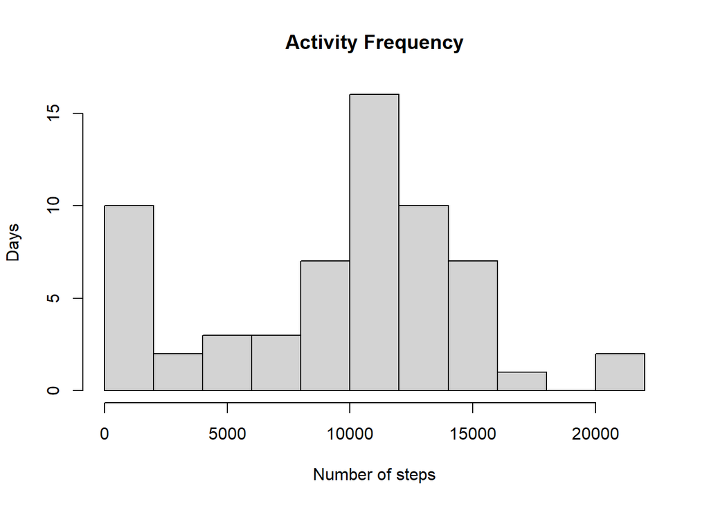

```r
stepArray <- c()
for (i in 1:length(dailyActivity)){
  stepArray <- cbind(stepArray,dailyActivity[[i]]$step)
}
totalStep <- colSums (stepArray, na.rm = TRUE, dims = 1)
hist(totalStep, breaks=10, xlab="Number of steps", ylab="Days", main = "Activity Frequency")
```

#### 3. Mean and median number of steps taken each day. Code below calculates mean and median number of steps taken each day

```r
meanSteps <- colMeans(stepArray, na.rm = TRUE, dims = 1)
medianSteps <-colMedians(stepArray, na.rm = TRUE, dims = 1)
sumTable <- data.frame(Date,round(meanSteps, digits = 0), round(medianSteps, digits = 0))
names(sumTable) <- c("Date", "Interval Mean", "Interval Median")
knitr::kable(sumTable, format = "markdown")
```

| Date | Interval Mean | Interval Median |
| --- | --- | --- |
| 2012-10-01 | NaN | NaN |
| 2012-10-02 | 0 | 0 |
| 2012-10-03 | 39 | 0 |
| 2012-10-04 | 42 | 0 |
| 2012-10-05 | 46 | 0 |
| 2012-10-06 | 54 | 0 |
| 2012-10-07 | 38 | 0 |
| 2012-10-08 | NaN | NaN |
| 2012-10-09 | 44 | 0 |
| 2012-10-10 | 34 | 0 |
| 2012-10-11 | 36 | 0 |
| 2012-10-12 | 60 | 0 |
| 2012-10-13 | 43 | 0 |
| 2012-10-14 | 52 | 0 |
| 2012-10-15 | 35 | 0 |
| 2012-10-16 | 52 | 0 |
| 2012-10-17 | 47 | 0 |
| 2012-10-18 | 35 | 0 |
| 2012-10-19 | 41 | 0 |
| 2012-10-20 | 36 | 0 |
| 2012-10-21 | 31 | 0 |
| 2012-10-22 | 47 | 0 |
| 2012-10-23 | 31 | 0 |
| 2012-10-24 | 29 | 0 |
| 2012-10-25 | 9 | 0 |
| 2012-10-26 | 24 | 0 |
| 2012-10-27 | 35 | 0 |
| 2012-10-28 | 40 | 0 |
| 2012-10-29 | 17 | 0 |
| 2012-10-30 | 34 | 0 |
| 2012-10-31 | 54 | 0 |
| 2012-11-01 | NaN | NaN |
| 2012-11-02 | 37 | 0 |
| 2012-11-03 | 37 | 0 |
| 2012-11-04 | NaN | NaN |
| 2012-11-05 | 36 | 0 |
| 2012-11-06 | 29 | 0 |
| 2012-11-07 | 45 | 0 |
| 2012-11-08 | 11 | 0 |
| 2012-11-09 | NaN | NaN |
| 2012-11-10 | NaN | NaN |
| 2012-11-11 | 44 | 0 |
| 2012-11-12 | 37 | 0 |
| 2012-11-13 | 25 | 0 |
| 2012-11-14 | NaN | NaN |
| 2012-11-15 | 0 | 0 |
| 2012-11-16 | 19 | 0 |
| 2012-11-17 | 50 | 0 |
| 2012-11-18 | 52 | 0 |
| 2012-11-19 | 31 | 0 |
| 2012-11-20 | 16 | 0 |
| 2012-11-21 | 44 | 0 |
| 2012-11-22 | 71 | 0 |
| 2012-11-23 | 74 | 0 |
| 2012-11-24 | 50 | 0 |
| 2012-11-25 | 41 | 0 |
| 2012-11-26 | 39 | 0 |
| 2012-11-27 | 47 | 0 |
| 2012-11-28 | 35 | 0 |
| 2012-11-29 | 24 | 0 |
| 2012-11-30 | NaN | NaN |

#### 4. Time series plot of the average number of steps taken

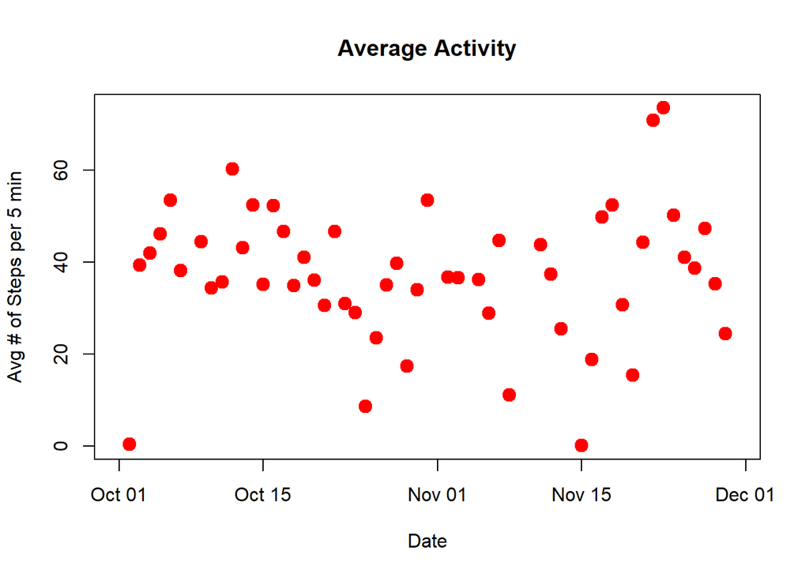

```r
plot(Date, meanSteps, xlab="Date", ylab="Avg # of Steps per 5 min", main = "Average Activity",
     pch =19, col = "red", cex = 1.5)
```

#### 5. The 5-minute interval that, on average, contains the maximum number of steps

```r
intervalMean=rowMeans(stepArray, na.rm = TRUE, dims = 1)
intervalMeanMax=which(intervalMean == max(intervalMean))
sprintf("The 5-minute interval that, on average, contains the maximum number of steps: %d",interval[intervalMeanMax])
```

```
## [1] "The 5-minute interval that, on average, contains the maximum number of steps: 835"
```

#### 6. Code to describe and show a strategy for imputing missing data.

Entry of 0 steps per 5 minute interval is considered valid and not imputed, only days with missing data are imputed, weekdays are imputed with average weekday activity, weekends are imputed with average weekend activity. Data is stored in *stepArray* array.

```r
WeedayIndex <- unname(which(isWeekday(Date) ==TRUE))
WeekendIndex <- unname(which(isWeekend(Date) ==TRUE))
NAWeekdayIndex <- unname(which(colSums(is.na(stepArray)) >0 & isWeekday(Date)))
NAWeekendIndex <- unname(which(colSums(is.na(stepArray)) >0 & isWeekend(Date)))

WeekdayIndex <- WeedayIndex[-which (WeedayIndex %in% NAWeekdayIndex)]
WeekendIndex <- WeekendIndex[-which (WeekendIndex %in% NAWeekendIndex)]

avgWeekdayActivity=round(rowMeans(stepArray[,WeekdayIndex],na.rm = TRUE, dims = 1), digits = 0) # average weekday activity
avgWeekendActivity=round(rowMeans(stepArray[,WeekendIndex],na.rm = TRUE, dims = 1), digits = 0) # average weekend activity

stepArray[,NAWeekdayIndex] <- avgWeekdayActivity
stepArray[,NAWeekendIndex] <- avgWeekendActivity
```

#### 7. Histogram of the total number of steps taken each day after missing values are imputed

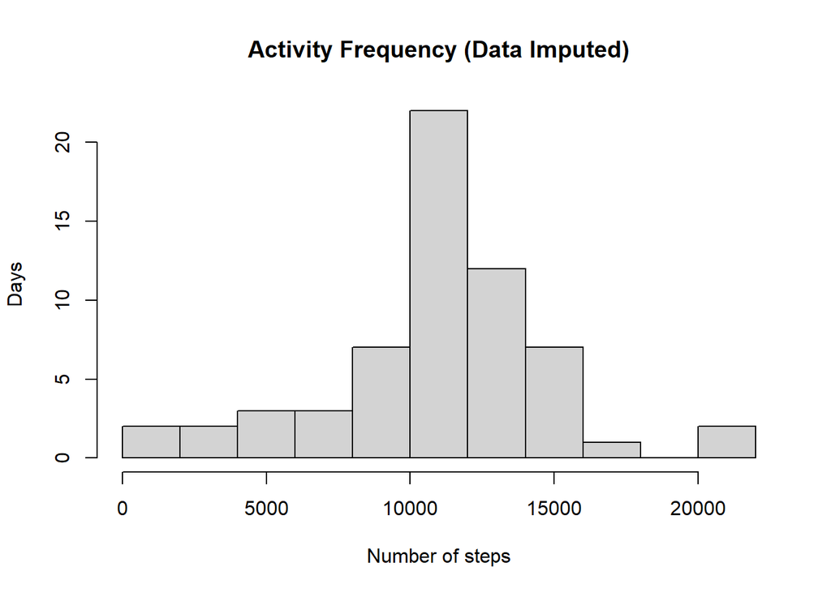

```r
totalStep <- colSums (stepArray, na.rm = TRUE, dims = 1)
hist(totalStep, breaks=10, xlab="Number of steps", ylab="Days", main = "Activity Frequency (Data Imputed)")
```

#### 8. Panel plot comparing the average number of steps taken per 5-minute interval across weekdays and weekends

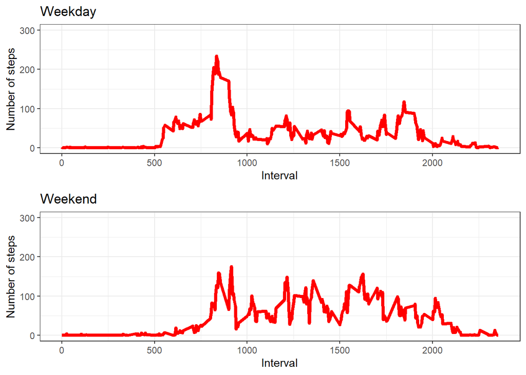

```r
avgActivity <- data.frame(interval, avgWeekdayActivity, avgWeekendActivity)
names(avgActivity) <- c("Interval", "Weekday", "Weekend")

g1 <- ggplot (data = avgActivity, aes(x = Interval, y = Weekday)) +
  geom_line(linewidth = 1.5, color = "red") +
  xlab("Interval") + ylab ("Number of steps") + ggtitle("Weekday") +
  ylim(0,300) +
  theme_bw()

g2 <- ggplot (data = avgActivity, aes(x = Interval, y = Weekend)) +
  geom_line(linewidth = 1.5, color = "red") +
  xlab("Interval") + ylab ("Number of steps") + ggtitle("Weekend") +
  ylim(0,300)+
  theme_bw()
ggarrange(g1,g2,nrow = 2)
```